# Model Dependensi Spasial

Ummul Auliyah Syam

2024-11-13

# MODEL DEPENDENSI SPASIAL

Tahapan regresi spasial untuk data yang memiliki efek dependensi spasial adalah sebagai berikut:

1. Eksplorasi Data
2. Ordinary Least Square atau Regresi Klasik dan Uji Asumsi
3. Menentukan Matriks Pembobot Spasial
4. Uji Efek Dependensi Spasial dan Heterogenitas Spasial
5. Regresi Spasial dan Uji Asumsi
6. Kebaikan Model

## Package

Berikut adalah package yang digunakan:

```r
library(spdep)        # Analisis data spasial: spatial autocorrelation, spatial regression
library(sp)           # Struktur data untuk manipulasi data spasial (poligon, titik, dll)
library(sf)           # Mengelola data spasial dengan standar Simple Features (sf)
library(readxl)       # Membaca file Excel (format .xls dan .xlsx)
library(openxlsx)     # Membuat, membaca, dan menulis file Excel (lebih cepat dari readxl)
library(corrplot)     # Membuat visualisasi korelasi dalam bentuk plot
library(DescTools)    # Kumpulan fungsi statistik deskriptif dan inferensial
library(nortest)      # Melakukan uji normalitas (Anderson-Darling, Lilliefors, dll)
library(car)          # Fungsi regresi linear dan diagnostik model (vif, durbinWatsonTest, dll)
library(spatialreg)   # Estimasi model regresi spasial (SAR, SEM, SLM)
library(lmtest)       # Fungsi untuk menguji model regresi (heteroskedastisitas, serial correlation)
library(dplyr)        # Manipulasi data seperti filter, select, mutate, dan summarise
library(RColorBrewer) # Skema palet warna yang dapat digunakan dalam visualisasi
library(ggplot2)      # Membuat grafik statistik dengan pendekatan Grammar of Graphics
```

## Import Data

Data yang digunakan terdiri dari dua jenis data:

1. Data Polygon (Peta Pulau Jawa, dengan extension .shp)
2. Dataframe (Peubah Y dan X yang dilibatkan)

Berikut ini adalah peubah-peubah yang digunakan:

- Peubah Y
- Peubah X1
- Peubah X2

Data dapat di download [disini](https://drive.google.com/drive/folders/1lxIvwhOLLJnIar9oX6U0Oj1FlrqqYyMf?usp=sharing)

```r
data <- read.csv("data-06.csv")
head(data)
```

```
##   ID_KAB    PROPINSI              KAB     long       lat     y    x1   x2
## 1   3101 DKI JAKARTA KEPULAUAN SERIBU 106.4933 -5.796823 27.35  89.5 50.0
## 2   3171 DKI JAKARTA  JAKARTA SELATAN 106.8100 -6.272549 36.22 103.1 52.5
## 3   3172 DKI JAKARTA    JAKARTA TIMUR 106.9003 -6.255373 27.46  90.3 48.7
## 4   3173 DKI JAKARTA    JAKARTA PUSAT 106.8351 -6.181230 29.17  88.5 54.9
## 5   3174 DKI JAKARTA    JAKARTA BARAT 106.7483 -6.165469 32.16  99.6 48.1
## 6   3175 DKI JAKARTA    JAKARTA UTARA 106.8695 -6.129185 32.67 102.2 45.8
```

```r
dim(data)
```

```
## [1] 119   8
```

Data terdiri dari 119 kabupaten/kota di Pulau Jawa. Peubah yang dilibatkan diantaranya adalah satu peubah respon (Y) dan dua peubah penjelas (X1 dan X2)

Berikut ini adalah peta Pula Jawa:

```r
peta <- st_read(dsn ="Jawamap", layer = "jawa")
peta
```

```
## Simple feature collection with 119 features and 5 fields
## Geometry type: MULTIPOLYGON
## Dimension:     XY
## Bounding box:  xmin: 105.0998 ymin: -8.78036 xmax: 116.2702 ymax: -5.048857
## Geodetic CRS:  WGS 84
## First 10 features:
##    PROVNO KABKOTNO    PROVINSI           KABKOT ID2013
## 1      31       01 DKI JAKARTA KEPULAUAN SERIBU   3101
## 2      31       71 DKI JAKARTA  JAKARTA SELATAN   3171
## 3      31       72 DKI JAKARTA    JAKARTA TIMUR   3172
## 4      31       73 DKI JAKARTA    JAKARTA PUSAT   3173
## 5      31       74 DKI JAKARTA    JAKARTA BARAT   3174
## 6      31       75 DKI JAKARTA    JAKARTA UTARA   3175
## 7      32       01  JAWA BARAT            BOGOR   3201
## 8      32       02  JAWA BARAT         SUKABUMI   3202
## 9      32       03  JAWA BARAT          CIANJUR   3203
## 10     32       04  JAWA BARAT          BANDUNG   3204
##                          geometry
## 1  MULTIPOLYGON (((106.3842 -5...
## 2  MULTIPOLYGON (((106.8491 -6...
## 3  MULTIPOLYGON (((106.9719 -6...
## 4  MULTIPOLYGON (((106.8788 -6...
## 5  MULTIPOLYGON (((106.711 -6....
## 6  MULTIPOLYGON (((106.969 -6....
## 7  MULTIPOLYGON (((106.994 -6....
## 8  MULTIPOLYGON (((106.9652 -6...
## 9  MULTIPOLYGON (((107.2843 -6...
## 10 MULTIPOLYGON (((107.75 -6.8...
```

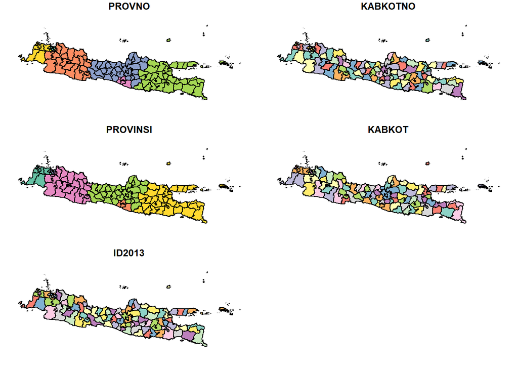

```r
plot(peta, main = "Peta Pulau Jawa")
```

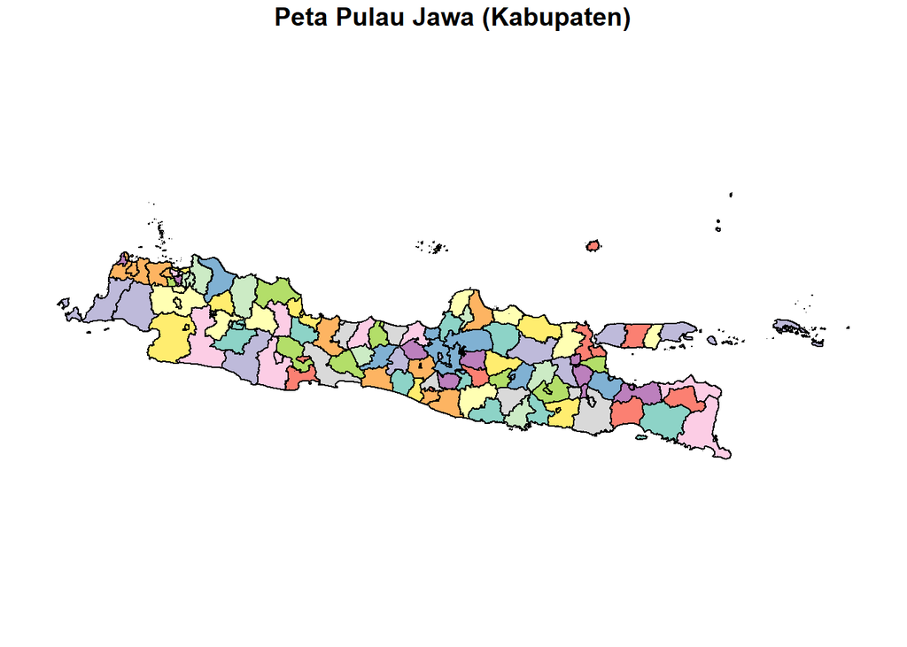

```r
plot(peta[4], main = "Peta Pulau Jawa (Kabupaten)")
```

## Eksplorasi Data

### Mengecek Missing Value

```r
data[!complete.cases(data),]
```

```
## [1] ID_KAB   PROPINSI KAB      long     lat      y        x1       x2
## <0 rows> (or 0-length row.names)
```

Hasil pengecekan **missing value** menunjukkan bahwa tidak terdapat **missing value** pada data.

### Ringkasan Statistik Deskriptif

Hasil statistik deskriptif dari data secara deskriptif ditunjukkan sebagai berikut:

```r
summary(data[,-c(1,2)])
```

```
##      KAB                 long            lat               y
##  Length:119         Min.   :105.8   Min.   :-8.365   Min.   :13.72
##  Class :character   1st Qu.:107.9   1st Qu.:-7.653   1st Qu.:22.07
##  Mode  :character   Median :110.2   Median :-7.258   Median :25.40
##                     Mean   :110.0   Mean   :-7.199   Mean   :25.53
##                     3rd Qu.:111.8   3rd Qu.:-6.820   3rd Qu.:29.20
##                     Max.   :114.2   Max.   :-5.797   Max.   :36.22
##        x1               x2
##  Min.   : 80.10   Min.   :25.10
##  1st Qu.: 87.25   1st Qu.:33.20
##  Median : 92.20   Median :41.20
##  Mean   : 93.04   Mean   :40.78
##  3rd Qu.: 99.85   3rd Qu.:49.25
##  Max.   :105.00   Max.   :55.00
```

```r
# Menunjukkan kab/kota dengan Y tertinggi
kab_max <- data %>%
  arrange(desc(y)) %>%
  slice(1)

print(paste("Kabupaten/kota dengan Y tertinggi adalah", kab_max$KAB))
```

```
## [1] "Kabupaten/kota dengan Y tertinggi adalah JAKARTA SELATAN"
```

```r
# Menunjukkan kab/kota dengan Y terendah
kab_min <- data %>%
  arrange(y) %>%
  slice(1)

print(paste("Kabupaten/kota dengan Y terendah adalah", kab_min$KAB))
```

```
## [1] "Kabupaten/kota dengan Y terendah adalah KLATEN"
```

Berdasarkan output di atas diketahui bahwa Y tertinggi di Pulau Jawa adalah Kota Jakarta Selatan sebesar 36.22, sedangkan Y terendah adalah Kabupaten Klaten sebesar 13.72. Rata-rata Y kab/kota di Pulau Jawa adalah 25.53.

### Boxplot - Identifikasi Pencilan

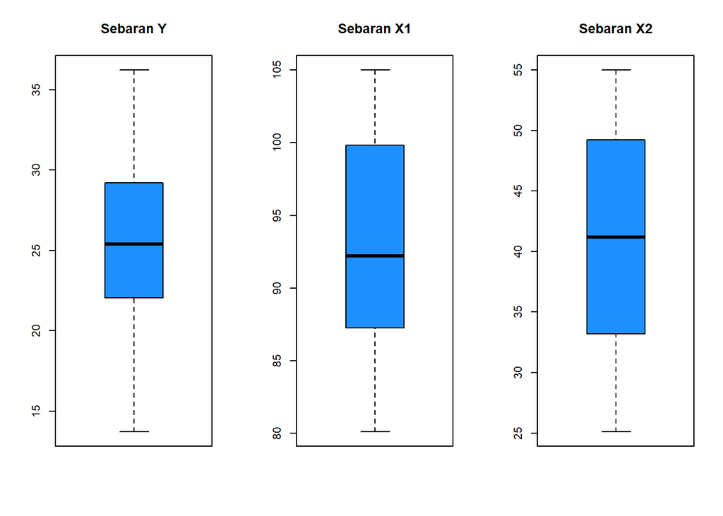

```r
par(mfrow=c(1,3))
boxplot(data$y,main = "Sebaran Y", col="dodgerblue")
boxplot(data$x1,main = "Sebaran X1", col="dodgerblue")
boxplot(data$x2,main = "Sebaran X2", col="dodgerblue")
```

Berdasarkan Boxplot dari peubah respon dan peubah penjelas diatas diketahui bahwa tidak terdapat pencilan pada data.

### Hubungan antara Peubah Respon dan Peubah Penjelas

Scatter plot ini untuk melihat pola hubungan Y dengan masing-masing peubah X1 dan X2 serta pola hubungan antar peubah X.

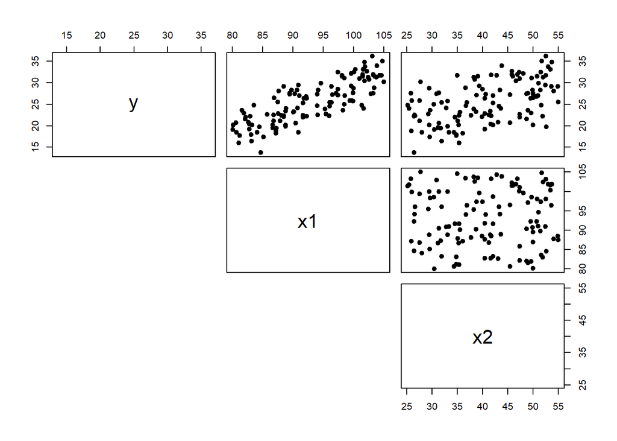

```r
pairs(data[,6:8], pch = 19, lower.panel = NULL)
```

Berdasarkan scatter plot di atas, tampak adanya pola hubungan linear positif antara peubah X1 maupun X2 terhadap peubah Y, dengan X1 tampak memiliki hubungan yang lebih kuat. Selain itu, tampak juga bahwa antar peubah penjelas tidak memiliki hubungan karena tidak memiliki pola tertentu.

### Korelasi antar Peubah

Nilai korelasi antar peubah adalah sebagai berikut:

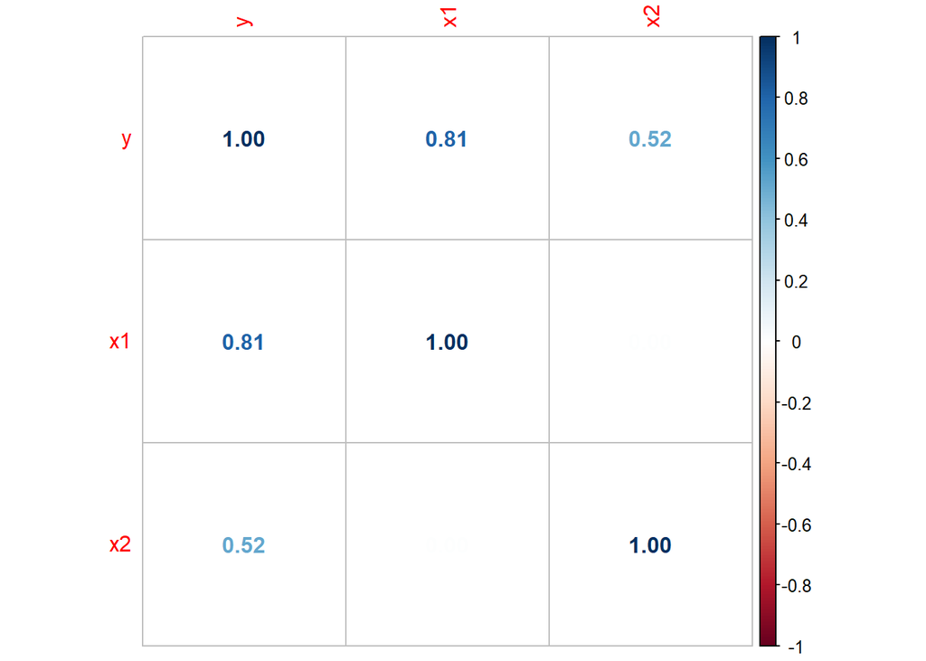

```r
corrplot(cor(data[,6:8]), method = "number")
```

```r
cor(data[,4:7])
```

```
##             long         lat          y          x1
## long  1.00000000 -0.74541782 -0.1306153 -0.08974212
## lat  -0.74541782  1.00000000  0.1679668  0.07479095
## y    -0.13061532  0.16796681  1.0000000  0.80963262
## x1   -0.08974212  0.07479095  0.8096326  1.00000000
```

*Uji Korelasi antarpeubah*

**Korelasi Y dengan X1**

Ho: Tidak terdapat korelasi antara peubah Y dan X1

H1: Ada korelasi antara peubah Y dan X1

Keputusan: Tolak Ho jika p-value < alpha=0.05

```r
#Y dengan X1
cor.test(data$y, data$x1)
```

```
##
##  Pearson's product-moment correlation
##
## data:  data$y and data$x1
## t = 14.921, df = 117, p-value < 2.2e-16
## alternative hypothesis: true correlation is not equal to 0
## 95 percent confidence interval:
##  0.7370471 0.8637532
## sample estimates:
##       cor
## 0.8096326
```

Kesimpulan: Tolak Ho berarti pada taraf nyata 5% (p-value < 0.05), Terdapat korelasi antara peubah Y dan X1.

**Korelasi Y dengan X2**

Ho: Tidak terdapat korelasi antara peubah Y dan X2

H1: Ada korelasi antara peubah Y dan X2

Keputusan: Tolak Ho jika p-value < alpha=0.05

```r
#Y dengan X2
cor.test(data$y, data$x2)
```

```
##
##  Pearson's product-moment correlation
##
## data:  data$y and data$x2
## t = 6.5822, df = 117, p-value = 1.374e-09
## alternative hypothesis: true correlation is not equal to 0
## 95 percent confidence interval:
##  0.3749256 0.6399554
## sample estimates:
##       cor
## 0.5198398
```

Kesimpulan: Tolak Ho berarti pada taraf nyata 5% (p-value < 0.05) terdapat korelasi antara peubah Y dan X2.

### Sebaran Spasial Data

*Sebaran Spasial Y*

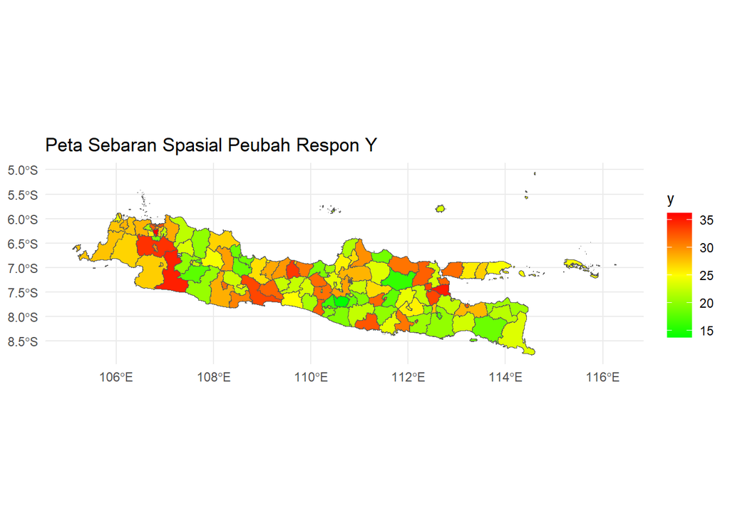

```r
k=101
colfunc <- colorRampPalette(c("green", "yellow","red"))

peta$y <- data$y

# Plot menggunakan ggplot2
ggplot(peta) +
  geom_sf(aes(fill = y)) +
  scale_fill_gradientn(colors = colfunc(k)) +
  labs(title = "Peta Sebaran Spasial Peubah Respon Y") +
  theme_minimal()
```

Berdasarkan plot di atas, dapat dilihat adanya kecenderungan pola bergerombol dengan wilayah tetangganya pada peubah Y di Pulau Jawa. Hal ini tampak dari gradasi warna yang cenderung mengumpul. Artinya terdapat kemiripan antar kabupaten/kota terhadap sebaran Y sehingga terindikasi adanya autokorelasi spasial positif.

*Sebaran Spasial X1*

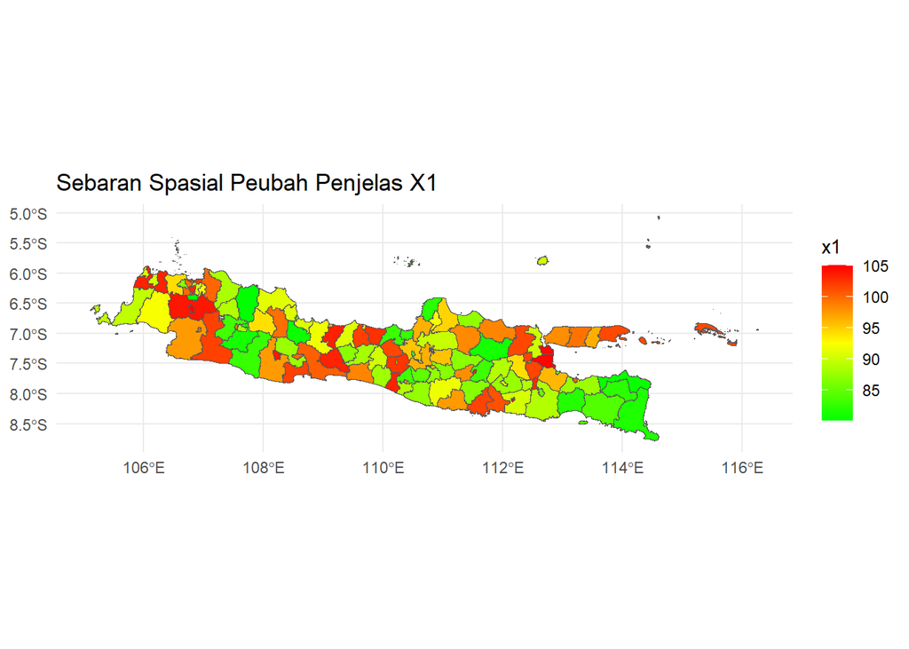

```r
peta$x1<- data$x1

# Plot menggunakan ggplot2
ggplot(peta) +
  geom_sf(aes(fill = x1)) +
  scale_fill_gradientn(colors = colfunc(k)) +
  labs(title = "Sebaran Spasial Peubah Penjelas X1") +
  theme_minimal()
```

*Sebaran Spasial X2*

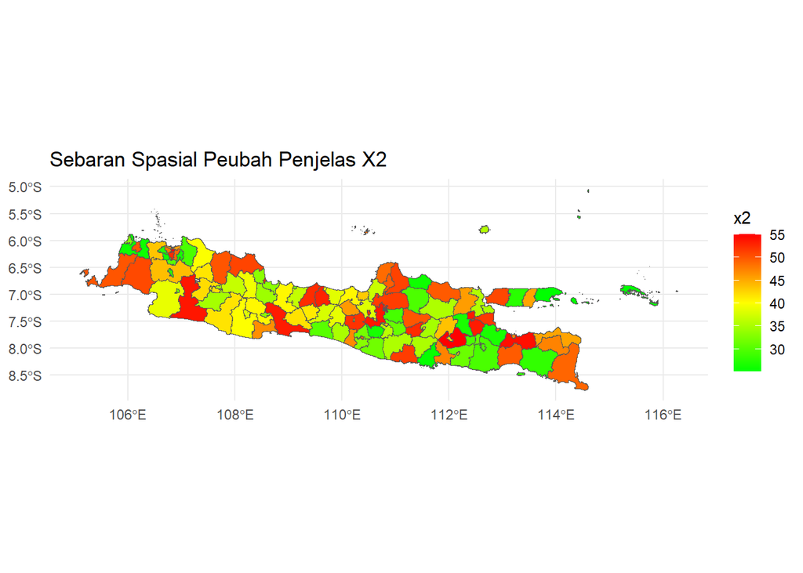

```r
peta$x2<- data$x2

# Plot menggunakan ggplot2
ggplot(peta) +
  geom_sf(aes(fill = x2)) +
  scale_fill_gradientn(colors = colfunc(k)) +
  labs(title = "Sebaran Spasial Peubah Penjelas X2") +
  theme_minimal()
```

## Matriks Pembobot Spasial

Matriks pembobot spasial dapat berdasarkan aspek ketetanggaan dan aspek jarak. Matriks ketetanggaan yang dicobakan dalam analisis ini yaitu rook contiguity dan queen contiguity sedangkan berdasarkan aspek jarak digunakan k-nearest neighbor (KNN), radial distance weight (RDW), inverse distance weight (IDW), dan exponential distance weight (IDW).

### Matriks Bobot Berdasarkan Ketetanggan

Pada pemeriksaan bobot apasial berdasarkan matriks ketetanggaan terdapat masalah, yaitu ada 1 daerah yang tidak memiliki tetangga, sehingga diaktifkan opsi `zero.policy = TRUE`.

#### Queen Contiguity

Matriks pembobot spasial **queen contiguity** lebih luas daripada rook contiguity karena wilayah-wilayah dianggap bertetangga jika mereka berbagi **sisi** atau **titik sudut**.

**Karakteristik:**

- Dua poligon dianggap bertetangga jika mereka berbagi batas (baik sisi maupun titik sudut).
- Jika dua wilayah memiliki titik atau sisi yang bersinggungan, maka elemen matriks pembobot diberi nilai 1.

Berikut ilustrasi dari *queen contiguity*:

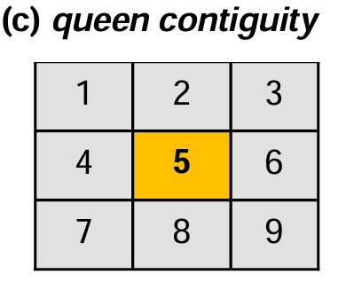

```r
# Memvalidasi geometri dalam objek sf
peta <- st_make_valid(peta)
# Konversi objek sf ke objek sp
sp.peta <- as(peta, "Spatial")

# Mengakses slot polygons dari objek sp
sp.polygons <- SpatialPolygons(sp.peta@polygons)
queen <- poly2nb(sp.peta, queen = T)
queen
```

```
## Neighbour list object:
## Number of regions: 119
## Number of nonzero links: 522
## Percentage nonzero weights: 3.68618
## Average number of links: 4.386555
## 1 region with no links:
## 1
## 3 disjoint connected subgraphs
```

```r
W.queen <- nb2listw(queen, style='W',zero.policy=TRUE)
qc = moran.test(data$y, W.queen,randomisation=T,
alternative="greater", zero.policy = TRUE)
qc
```

```
##
##  Moran I test under randomisation
##
## data:  data$y
## weights: W.queen
## n reduced by no-neighbour observations
##
## Moran I statistic standard deviate = 1.3921, p-value = 0.08195
## alternative hypothesis: greater
## sample estimates:
## Moran I statistic       Expectation          Variance
##       0.085984133      -0.008547009       0.004611252
```

Pengujian hipotesis dapat pula dilakukan dengan melibatkan algoritma monte carlo seperti di bawah ini.

```r
moran.mc(data$y, listw = W.queen, zero.policy = TRUE, nsim = 99)
```

```
##
##  Monte-Carlo simulation of Moran I
##
## data:  data$y
## weights: W.queen
## number of simulations + 1: 100
##
## statistic = 0.085984, observed rank = 93, p-value = 0.07
## alternative hypothesis: greater
```

#### Rook Contiguity

Matriks pembobot spasial rook contiguity didasarkan pada konsep bahwa dua wilayah dianggap bertetangga jika mereka berbagi sisi batas.

- Karakteristik:
  - Dua poligon dianggap bertetangga jika mereka memiliki batas yang bersinggungan di sepanjang sisi yang sama (tidak hanya di titik sudut).
  - Jika dua wilayah bertetangga, nilai elemen matriks pembobot adalah 1; jika tidak, maka nilai elemen tersebut adalah 0.

Berikut ilustrasi dari *rook contiguity*

[figure not shown]

```r
rook <- poly2nb(sp.peta, queen = F)
rook
```

```
## Neighbour list object:
## Number of regions: 119
## Number of nonzero links: 518
## Percentage nonzero weights: 3.657934
## Average number of links: 4.352941
## 1 region with no links:
## 1
## 3 disjoint connected subgraphs
```

```r
W.rook <- nb2listw(rook, style='W',zero.policy=TRUE)
rc = moran.test(data$y, W.rook,randomisation=T,
alternative="greater", zero.policy = TRUE)
rc
```

```
##
##  Moran I test under randomisation
##
## data:  data$y
## weights: W.rook
## n reduced by no-neighbour observations
##
## Moran I statistic standard deviate = 1.5987, p-value = 0.05495
## alternative hypothesis: greater
## sample estimates:
## Moran I statistic       Expectation          Variance
##       0.100243070      -0.008547009       0.004630949
```

Pengujian hipotesis dapat pula dilakukan dengan melibatkan algoritma monte carlo seperti di bawah ini.

```r
moran.mc(data$y, listw = W.rook, zero.policy = TRUE, nsim = 99)
```

```
##
##  Monte-Carlo simulation of Moran I
##
## data:  data$y
## weights: W.rook
## number of simulations + 1: 100
##
## statistic = 0.10024, observed rank = 95, p-value = 0.05
## alternative hypothesis: greater
```

### Matriks Bobot Berdasarkan Jarak

```r
# Menghitung centroid dari setiap unit spasial
centroids <- st_centroid(peta)
# Ekstrak koordinat centroid
longlat <- st_coordinates(centroids)

# Tambahkan koordinat long dan lat ke objek peta
peta$long <- longlat[, 1]  # Kolom X (long)
peta$lat  <- longlat[, 2]  # Kolom Y (lat)
```

```r
coords <- peta[c("long","lat")]
#class(coords)
koord <- as.data.frame(coords)
jarak<-dist(longlat, method = "euclidean")
m.jarak<-as.matrix(jarak)
```

#### K-Nearest Neighbor

Matriks bobot k-nearest neighbor menentukan tetangga berdasarkan sejumlah tetangga terdekat (`k`) yang dipilih untuk setiap titik atau wilayah.

- **Karakteristik:**
  - Untuk setiap titik/wilayah, tetangga yang dipilih adalah titik/wilayah yang paling dekat (berdasarkan jarak Euclidean atau jarak lainnya).
  - Nilai matriks bobot diberikan 1 jika suatu titik berada dalam `k` tetangga terdekat dari titik lain, dan 0 jika tidak.
- **Contoh:** Misalkan `k = 3`, artinya setiap titik akan memiliki 3 tetangga terdekat. Matriks bobot akan memiliki 1 di elemen yang mewakili tetangga terdekat, dan 0 di elemen lainnya.

Digunakan 5 tetangga terdekat (k=5)

```r
# k = 5
W.knn<-knn2nb(knearneigh(longlat,k=5,longlat=TRUE))
W.knn.s <- nb2listw(W.knn,style='W')

MI.knn <- moran(data$y,W.knn.s,n=length(W.knn.s$neighbours),S0=Szero(W.knn.s))
mt1 = moran.test(data$y,W.knn.s,randomisation = T,alternative = "greater")
mt1
```

```
##
##  Moran I test under randomisation
##
## data:  data$y
## weights: W.knn.s
##
## Moran I statistic standard deviate = 2.1802, p-value = 0.01462
## alternative hypothesis: greater
## sample estimates:
## Moran I statistic       Expectation          Variance
##       0.107628130      -0.008474576       0.002835976
```

#### Radial Distance Weight

Matriks bobot radial distance mendefinisikan tetangga berdasarkan jarak geografis. Setiap titik atau wilayah dianggap sebagai tetangga jika jaraknya dari titik/wilayah pusat berada dalam jarak radius tertentu.

- **Karakteristik:**
  - Tetangga dipilih berdasarkan jarak dari titik pusat hingga ke titik lain dalam radius tertentu (`r`). Jika titik lain berada dalam radius tersebut, maka nilai dalam matriks bobot adalah 1; jika tidak, maka 0.
  - Jarak dihitung berdasarkan metrik spasial seperti jarak Euclidean.
- **Contoh:** Jika radius yang ditentukan adalah 10 km, maka setiap titik atau wilayah yang berada dalam jarak 10 km dari titik pusat akan dianggap sebagai tetangga, dan bobot matriks akan diberikan 1.

```r
W.rdw <-dnearneigh(longlat,0,105,longlat=TRUE)
W.rdw.s <- nb2listw(W.rdw,style='W')

MI.rdw <- moran(data$y,W.rdw.s,n=length(W.rdw.s$neighbours),S0=Szero(W.rdw.s))
mt2 = moran.test(data$y,W.rdw.s,randomisation = T,alternative = "greater")
mt2
```

```
##
##  Moran I test under randomisation
##
## data:  data$y
## weights: W.rdw.s
##
## Moran I statistic standard deviate = 0.82869, p-value = 0.2036
## alternative hypothesis: greater
## sample estimates:
## Moran I statistic       Expectation          Variance
##      0.0148447999     -0.0084745763      0.0007918598
```

#### Invers Distance Weight

Matriks pembobot **Inverse Distance Weight (IDW)** menentukan bobot berdasarkan kebalikan dari jarak antar titik atau wilayah. Semakin dekat dua titik, semakin besar bobot yang diberikan.

- **Karakteristik:**
  - Bobot dihitung sebagai kebalikan dari jarak, biasanya dengan rumus:

    $w_{ij}=\frac{1}{d_{ij}^p}$
  - Di mana $d_{ij}$ adalah jarak antara titik `i` dan `j`, dan `p` adalah eksponen yang menentukan seberapa cepat bobot menurun seiring bertambahnya jarak. Biasanya `p` bernilai 1 atau 2.
  - Titik atau wilayah yang lebih dekat memiliki bobot lebih besar, sementara yang lebih jauh memiliki bobot lebih kecil.
- **Contoh:** Jika jarak antara dua titik adalah 5 km, dan eksponen jarak adalah 2, maka bobot dihitung sebagai $\frac{1}{5^2} = 0.04$

Ditentukan nilai alpha=1 dan alpha=2

```r
alpha1=1
W.idw <-1/(m.jarak^alpha1)
diag(W.idw)<-0
rtot<-rowSums(W.idw,na.rm=TRUE)
W.idw.sd<-W.idw/rtot #row-normalized
W.idw.s = mat2listw(W.idw.sd,style='W')

MI.idw <- moran(data$y,W.idw.s,n=length(W.idw.s$neighbours),S0=Szero(W.idw.s))
mt3 = moran.test(data$y,W.idw.s,randomisation = T,alternative = "greater")
mt3
```

```
##
##  Moran I test under randomisation
##
## data:  data$y
## weights: W.idw.s
##
## Moran I statistic standard deviate = 2.3687, p-value = 0.008925
## alternative hypothesis: greater
## sample estimates:
## Moran I statistic       Expectation          Variance
##       0.040533196      -0.008474576       0.000428063
```

```r
alpha2=2
W.idw2<-1/(m.jarak^alpha2)
diag(W.idw2)<-0
rtot<-rowSums(W.idw2,na.rm=TRUE)
W.idw2.sd<-W.idw2/rtot #row-normalized
W.idw2.s = mat2listw(W.idw2.sd,style='W')

MI.idw2 <- moran(data$y,W.idw2.s,n=length(W.idw2.s$neighbours),S0=Szero(W.idw2.s))
mt4 = moran.test(data$y,W.idw2.s,randomisation = T,alternative = "greater")
mt4
```

```
##
##  Moran I test under randomisation
##
## data:  data$y
## weights: W.idw2.s
##
## Moran I statistic standard deviate = 1.9574, p-value = 0.02515
## alternative hypothesis: greater
## sample estimates:
## Moran I statistic       Expectation          Variance
##       0.088273381      -0.008474576       0.002442892
```

#### Exponential Distance Weight

Matriks **exponential distance weight** memberikan bobot yang menurun secara eksponensial seiring dengan peningkatan jarak antar unit spasial. Ini mirip dengan inverse distance weight, tetapi penurunan bobot terhadap jarak lebih tajam.

**Karakteristik:**

- Bobot dihitung berdasarkan rumus

  $w_{ij}=(-\alpha d_{ij})$

  dimana *α* adalah parameter yang mengatur kecepatan penurunan bobot berdasarkan jarak.
- Semakin besar jaraknya, semakin cepat bobot mendekati nol, tergantung pada nilai $\alpha$.
- Tidak ada ambang jarak tetap; semua unit bisa mempengaruhi unit lainnya, tetapi pengaruhnya menurun drastis dengan jarak yang lebih jauh.

Ditentukan alpha=1 dan alpha=2

```r
alpha=1
W.edw<-exp((-alpha)*m.jarak)
diag(W.edw)<-0
rtot<-rowSums(W.edw,na.rm=TRUE)
W.edw.sd<-W.edw/rtot #row-normalized
W.edw.s = mat2listw(W.edw.sd,style='W')

MI.edw <- moran(data$y,W.edw.s,n=length(W.edw.s$neighbours),S0=Szero(W.edw.s))
mt5 = moran.test(data$y,W.edw.s,randomisation = T,alternative = "greater")
mt5
```

```
##
##  Moran I test under randomisation
##
## data:  data$y
## weights: W.edw.s
##
## Moran I statistic standard deviate = 1.3022, p-value = 0.09643
## alternative hypothesis: greater
## sample estimates:
## Moran I statistic       Expectation          Variance
##      0.0099060556     -0.0084745763      0.0001992396
```

```r
alpha2=2
W.edw2<-exp((-alpha2)*m.jarak)
diag(W.edw2)<-0
rtot<-rowSums(W.edw2,na.rm=TRUE)
W.edw2.sd<-W.edw2/rtot #row-normalized
W.edw2.s = mat2listw(W.edw2.sd,style='W')
MI.edw2 <- moran(data$y,W.edw2.s,n=length(W.edw2.s$neighbours),S0=Szero(W.edw2.s))
mt6 = moran.test(data$y,W.edw2.s,randomisation = T,alternative = "greater")
mt6
```

```
##
##  Moran I test under randomisation
##
## data:  data$y
## weights: W.edw2.s
##
## Moran I statistic standard deviate = 1.875, p-value = 0.03039
## alternative hypothesis: greater
## sample estimates:
## Moran I statistic       Expectation          Variance
##      0.0328701345     -0.0084745763      0.0004862084
```

### Pemilihan Matriks Bobot Terbaik

Matriks pembobot spasial yang dipilih yaitu matriks yang menghasilkan nilai autokorelasi spasial yang tertinggi. Pemilihan matriks bobot juga dapat didasarkan pada matriks bobot dengan nilai indeks moran yang signifikan pada taraf 5%.

```r
MatriksBobot <- c("K-Nearest Neighbor (k=5)",
                  "Radial Distance Weight (dmax=60)",
                  "Invers Distance Weight (alpha=1)",
                  "Invers Distance Weight (alpha=2)",
                  "Exponential Distance Weight (alpha=1)",
                  "Exponential Distance Weight (alpha=2)",
                  "Rook Contiguity",
                  "Queen Contiguity")
IndeksMoran <- c(MI.knn$I,MI.rdw$I,MI.idw$I,MI.idw2$I,MI.edw$I,MI.edw2$I,rc$estimate[1],qc$estimate[1])
pv = c(mt1$p.value,mt2$p.value,mt3$p.value,mt4$p.value,mt5$p.value,mt6$p.value,rc$p.value,qc$p.value)
Matriks = cbind.data.frame(MatriksBobot, IndeksMoran,"p-value"=pv)
colnames(Matriks) <-c("Matriks Bobot", "Indeks Moran", "p-value")
Matriks
```

```
##                           Matriks Bobot Indeks Moran     p-value
## 1              K-Nearest Neighbor (k=5)  0.107628130 0.014622303
## 2      Radial Distance Weight (dmax=60)  0.014844800 0.203639555
## 3      Invers Distance Weight (alpha=1)  0.040533196 0.008925225
## 4      Invers Distance Weight (alpha=2)  0.088273381 0.025147563
## 5 Exponential Distance Weight (alpha=1)  0.009906056 0.096426630
## 6 Exponential Distance Weight (alpha=2)  0.032870135 0.030394142
## 7                       Rook Contiguity  0.100243070 0.054948820
## 8                      Queen Contiguity  0.085984133 0.081948463
```

```r
Matriks[Matriks$`p-value`< 0.05,]
```

```
##                           Matriks Bobot Indeks Moran     p-value
## 1              K-Nearest Neighbor (k=5)   0.10762813 0.014622303
## 3      Invers Distance Weight (alpha=1)   0.04053320 0.008925225
## 4      Invers Distance Weight (alpha=2)   0.08827338 0.025147563
## 6 Exponential Distance Weight (alpha=2)   0.03287013 0.030394142
```

Berdasakan hasil di atas, Matriks bobot yang memiliki nilai Indeks Moran yang signifikan pada taraf 5% adalah k-nearest neighbor (k=5), invers distance weight dengan alpha =1, invers distance weight dengan alpha=2, dan exponential distance weight dengan alpha=2.

Matriks bobot spasial yang memiliki Indeks Moran tertinggi adalah k-Nearest neighbor dengan 5 tetangga terdekat sehingga matriks tersebut dapat dipilih menjadi matriks pembobot spasial yang terbaik diantara matriks pembobot lainnya. Selanjutnya matriks pembobot yang digunakan dalam analisis adalah k-nearest neighbor dengan 5 tetangga terdekat.

## Model Regresi Klasik (OLS)

- Pemodelan Ordinary Least Square dan uji asumsi multikolinearitas, autokorelasi spasial, kehomogenan ragam, kenormalan sisaan.
- Matriks Bobot yang digunakan adalah k-nearest neighbor dengan 5 tetangga terdekat

### Metode OLS

```r
ols <- lm(y~x1+x2, data=data)
summary(ols)
```

```
##
## Call:
## lm(formula = y ~ x1 + x2, data = data)
##
## Residuals:
##     Min      1Q  Median      3Q     Max
## -4.5977 -0.8358  0.0369  0.9222  3.5927
##
## Coefficients:
##              Estimate Std. Error t value Pr(>|t|)
## (Intercept) -36.66154    1.72709  -21.23   <2e-16 ***
## x1            0.54223    0.01742   31.13   <2e-16 ***
## x2            0.28804    0.01447   19.90   <2e-16 ***
## ---
## Signif. codes:  0 '***' 0.001 '**' 0.01 '*' 0.05 '.' 0.1 ' ' 1
##
## Residual standard error: 1.392 on 116 degrees of freedom
## Multiple R-squared:  0.922,  Adjusted R-squared:  0.9206
## F-statistic: 685.3 on 2 and 116 DF,  p-value: < 2.2e-16
```

```r
print(paste("Nilai AIC OLS", AIC(ols)))
```

```
## [1] "Nilai AIC OLS 421.320527312512"
```

### Model Diagnostics

#### Uji Normalitas Sisaan

H0 : sisaan model menyebar normal H1 : sisaan model tidak menyebar normal

Tolak H0 jika p-value < 0.05

```r
err.ols <- residuals(ols)
ad.test(err.ols)
```

```
##
##  Anderson-Darling normality test
##
## data:  err.ols
## A = 0.48312, p-value = 0.2255
```

Karena p-value > 5%, maka gagal tolak H0. Artinya sisaan menyebar normal.

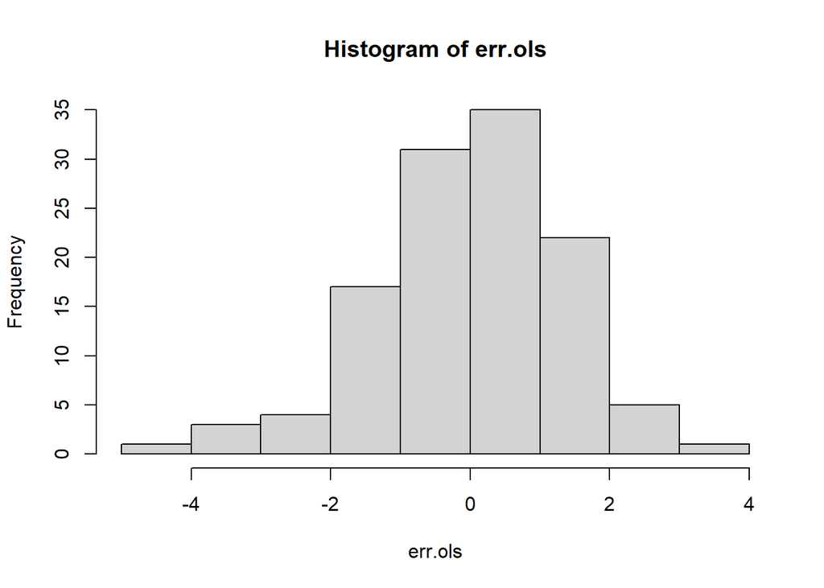

```r
hist(err.ols)
```

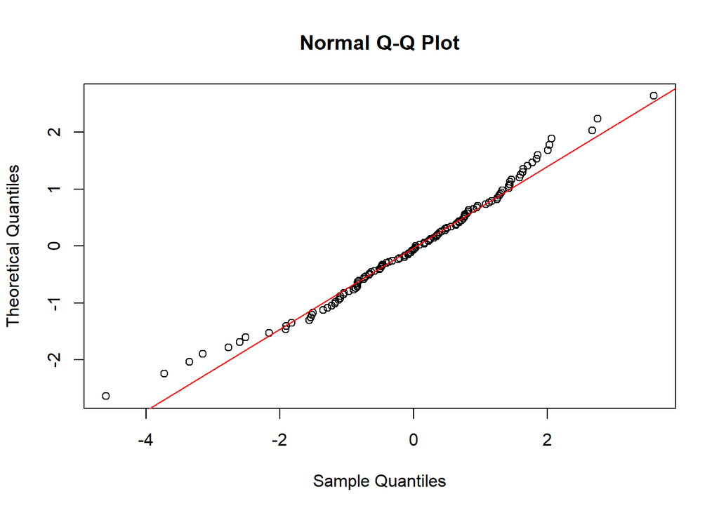

```r
qqnorm(err.ols,datax=T)
qqline(rnorm(length(err.ols),mean(err.ols),sd(err.ols)),datax=T, col="red")
```

Berdasarkan plot histogram dan normal Q-Q plot diatas terlihat bahwa sisaan menyebar normal.

#### Uji Kehomogenan Ragam

H0 : Ragam Sisaan Homogen H1 : Ragam Sisaan Tidak Homogen

```r
lmtest::bptest(ols)
```

```
##
##  studentized Breusch-Pagan test
##
## data:  ols
## BP = 1.557, df = 2, p-value = 0.4591
```

Karena p-value > 0.05, maka gagal tolak H0. Artinya ragam sisaan homogen

#### Uji Multikolinearitas

Pada regresi linear berganda perlu diperiksa persyaratan tidak adanya multikolinearitas antar peubah penjelas agar koefisien regresi yang diperoleh dapat dikatakan valid.

Pemeriksaan multikolinearitas dapat dilakukan dengan menggunakan nilai variance inflation factor (VIF). Multikolinearitas terjadi jika nilai VIF > 5.

```r
car::vif(ols)
```

```
##      x1      x2
## 1.00002 1.00002
```

Berdasarkan perhitungan, diperoleh nilai VIF < 5 yang menunjukkan tidak terjadi multikolinearitas antar peubah penjelas.

## Pengujian Efek Spasial

### Efek Dependensi Spasial

Untuk menentukan model dependensi spasial yang sesuai dengan data, terlebih dahulu dilakukan uji dependensi spasial. Secara umum ada dua macam uji dependensi spasia, yaitu Indeks Moran dan Uji Pengganda Lagrange (Lagrange Multiplier Test)

##### Uji Indeks Moran

Pengujian autokorelasi spasial menggunakan Indeks Moran yang memerlukan matriks pembobot spasial. Dalam kasus ini, digunakan matriks bobot terbaik yang telah diperoleh sebelumnya, yaitu k-nearest neighbor dengan 5 tetangga terdekat

H0 : Tidak ada autokorelasi spasial

H1 : Ada autokorelasi spasial

*Uji Indeks Moran pada Galat Model Regresi*

```r
ww = W.knn.s
lm.morantest(ols, listw=ww, alternative="two.sided", zero.policy = TRUE)
```

```
##
##  Global Moran I for regression residuals
##
## data:
## model: lm(formula = y ~ x1 + x2, data = data)
## weights: ww
##
## Moran I statistic standard deviate = 7.7062, p-value = 1.296e-14
## alternative hypothesis: two.sided
## sample estimates:
## Observed Moran I      Expectation         Variance
##      0.401296232     -0.008385587      0.002826244
```

```r
err.ols <- residuals(ols)
merr <- moran.test(err.ols, ww,randomisation=T,
           alternative="two.sided")
merr
```

```
##
##  Moran I test under randomisation
##
## data:  err.ols
## weights: ww
##
## Moran I statistic standard deviate = 7.7459, p-value = 9.488e-15
## alternative hypothesis: two.sided
## sample estimates:
## Moran I statistic       Expectation          Variance
##       0.401296232      -0.008474576       0.002798555
```

*Uji Indeks Moran pada Peubah Y*

```r
my <- moran.test(data$y, ww,randomisation=T,
           alternative="two.sided")
my
```

```
##
##  Moran I test under randomisation
##
## data:  data$y
## weights: ww
##
## Moran I statistic standard deviate = 2.1802, p-value = 0.02924
## alternative hypothesis: two.sided
## sample estimates:
## Moran I statistic       Expectation          Variance
##       0.107628130      -0.008474576       0.002835976
```

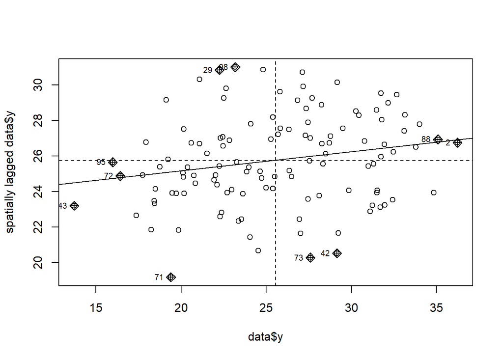

```r
moran.plot(data$y, ww, labels=data$KABKOT)
```

*Uji Indeks Moran pada Peubah X1*

```r
mx1 <- moran.test(data$x1, ww,randomisation=T,
           alternative="two.sided")
mx1
```

```
##
##  Moran I test under randomisation
##
## data:  data$x1
## weights: ww
##
## Moran I statistic standard deviate = 0.89468, p-value = 0.371
## alternative hypothesis: two.sided
## sample estimates:
## Moran I statistic       Expectation          Variance
##       0.039254520      -0.008474576       0.002846002
```

*Uji Indeks Moran pada Peubah X2*

```r
mx2 <- moran.test(data$x2, ww,randomisation=T,
           alternative="two.sided")
mx2
```

```
##
##  Moran I test under randomisation
##
## data:  data$x2
## weights: ww
##
## Moran I statistic standard deviate = -1.0874, p-value = 0.2768
## alternative hypothesis: two.sided
## sample estimates:
## Moran I statistic       Expectation          Variance
##      -0.066483348      -0.008474576       0.002845675
```

Berikut ini adalah hasil uji autokorelasi pada peubah respon, peubah penjelas, dan sisaan regresi

```r
Peubah = c("Y", "X1", "X2", "Sisaan")
Indeks_Moran = c(my$estimate[1], mx1$estimate[1], mx2$estimate[1], merr$estimate[1])
p_value = c(my$p.value, mx1$p.value, mx2$p.value, merr$p.value)

df1 = cbind.data.frame(Peubah, Indeks_Moran, p_value)
colnames(df1) <- c("Peubah", "Indeks Moran", "p-value")
df1
```

```
##   Peubah Indeks Moran      p-value
## 1      Y   0.10762813 2.924461e-02
## 2     X1   0.03925452 3.709605e-01
## 3     X2  -0.06648335 2.768471e-01
## 4 Sisaan   0.40129623 9.487767e-15
```

Berdasarkan hasil pengujian Indeks Moran di atas menunjukkan bahwa nilai indeks Moran pada peubah Y dan sisaan model regresi memiliki nilai p-value < 0.05 maka Tolak H0 sehingga autokorelasi spasial pada peubah tersebut berpengaruh nyata. Hal ini mengindikasikan bahwa terdapat ketergantungan spasial pada peubah y dan sisaan model regresi klasik. Terlihat pula nilai indeks moran positif pada peubah Y dan sisaan model regresi klasik yang menunjukkan adanya autokorelasi positif.

Sedangkan, nilai indeks moran pada peubah X1 dan X2 memiliki p-value > 0.05 maka gagal tolak H0 artinya tidak terdapat autokorelasi spasial peubah X1 dan X2 taraf nyata 5%.

Oleh karenanya, untuk mencari model yang lebih baik, kita dapat melakukan uji LM (lagrange multiplier) untuk mengidentifikasi model dependensi spasial yang dapat digunakan pada kasus ini.

##### Uji Lagrange Multiplier

```r
model <- lm.LMtests(ols,listw=ww,zero.policy = TRUE, test=c("LMerr","RLMerr","LMlag","RLMlag","SARMA"))
```

```
## Please update scripts to use lm.RStests in place of lm.LMtests
```

```r
summary(model)
```

```
##  Rao's score (a.k.a Lagrange multiplier) diagnostics for spatial
##  dependence
## data:
## model: lm(formula = y ~ x1 + x2, data = data)
## test weights: listw
##
##          statistic parameter   p.value
## RSerr      54.2452         1 1.770e-13 ***
## adjRSerr   31.9386         1 1.591e-08 ***
## RSlag      32.0571         1 1.497e-08 ***
## adjRSlag    9.7505         1  0.001793 **
## SARMA      63.9957         2 1.266e-14 ***
## ---
## Signif. codes:  0 '***' 0.001 '**' 0.01 '*' 0.05 '.' 0.1 ' ' 1
```

Output menunjukkan bahwa hasil uji LM model SAR, SEM, dan GSM serta uji robust LM SAR dan LM-SEM signifikan pada taraf 5%. Berdasarkan skema tersebut, maka kita dapat mencoba kandidat model SAR, SEM, dan SARMA.

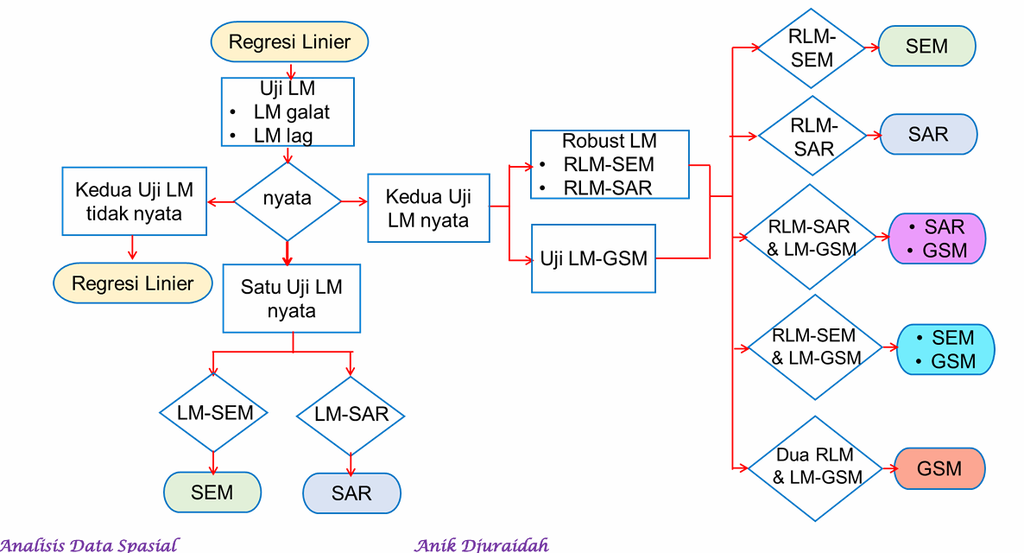

### Efek Heterogenitas Spasial

H0 : Ragam Sisaan Homogen

H1 : Ragam Sisaan Tidak Homogen

```r
lmtest::bptest(ols)
```

```
##
##  studentized Breusch-Pagan test
##
## data:  ols
## BP = 1.557, df = 2, p-value = 0.4591
```

Karena p-value > 0.05, maka Gagal Tolak H0. Artinya ragam sisaan homogen atau tidak terdapat efek heterogenitas spasial.

## Model Regresi Spasial

### Model SAR

```r
sar <- lagsarlm(y ~ x1 + x2, data = data, listw = ww)
summary(sar, Nagelkerke = T)
```

```
##
## Call:lagsarlm(formula = y ~ x1 + x2, data = data, listw = ww)
##
## Residuals:
##       Min        1Q    Median        3Q       Max
## -4.278572 -0.761564  0.016699  0.849727  2.695114
##
## Type: lag
## Coefficients: (asymptotic standard errors)
##               Estimate Std. Error z value  Pr(>|z|)
## (Intercept) -41.792688   1.851270 -22.575 < 2.2e-16
## x1            0.532067   0.015553  34.209 < 2.2e-16
## x2            0.290320   0.012806  22.671 < 2.2e-16
##
## Rho: 0.23233, LR test value: 25.223, p-value: 5.1057e-07
## Asymptotic standard error: 0.047605
##     z-value: 4.8803, p-value: 1.0593e-06
## Wald statistic: 23.817, p-value: 1.0593e-06
##
## Log likelihood: -194.0485 for lag model
## ML residual variance (sigma squared): 1.5135, (sigma: 1.2303)
## Nagelkerke pseudo-R-squared: 0.93687
## Number of observations: 119
## Number of parameters estimated: 5
## AIC: 398.1, (AIC for lm: 421.32)
## LM test for residual autocorrelation
## test value: 7.358, p-value: 0.0066764
```

Output di atas memperlihatkan bahwa koefisien Rho pada model SAR signifikan, dengan nilai AIC sebesar 398.1. Selain itu, terlihat pula hasil uji autokorelasi pada sisaan model memperlihatkan nilai p-value sebesar 0.0066764, artinya terdapat autokorelasi pada sisaan.

*Uji Asumsi Model SAR*

*Asumsi Kenormalan Sisaan*

H0 : galat model menyebar normal

H1 : galat model tidak menyebar normal

```r
err.sar<-residuals(sar)
ad.test(err.sar)
```

```
##
##  Anderson-Darling normality test
##
## data:  err.sar
## A = 0.28212, p-value = 0.6317
```

Karena p-value > 5%, maka gagal tolak H0. Artinya sisaan menyebar normal.

*Asumsi Kehomogenan Ragam*

H0 : Ragam Sisaan Homogen

H1 : Ragam Sisaan Tidak Homogen

```r
bptest.Sarlm(sar)
```

```
##
##  studentized Breusch-Pagan test
##
## data:
## BP = 2.6875, df = 2, p-value = 0.2609
```

Karena p-value > 5%, maka gagal tolak H0. Artinya ragam sisaan homogen.

*Uji Kebebasan Sisaan*

H0: Tidak ada autokorelasi spasial

H1: ada autokorelasi spasial

```r
moran.test(err.sar, ww, alternative="two.sided")
```

```
##
##  Moran I test under randomisation
##
## data:  err.sar
## weights: ww
##
## Moran I statistic standard deviate = 2.776, p-value = 0.005504
## alternative hypothesis: two.sided
## sample estimates:
## Moran I statistic       Expectation          Variance
##       0.138466721      -0.008474576       0.002801958
```

### Model SEM

```r
sem<-errorsarlm(y ~ x1 + x2,data=data, listw= ww)
summary(sem)
```

```
##
## Call:errorsarlm(formula = y ~ x1 + x2, data = data, listw = ww)
##
## Residuals:
##      Min       1Q   Median       3Q      Max
## -4.61465 -0.56031  0.16416  0.76534  2.46897
##
## Type: error
## Coefficients: (asymptotic standard errors)
##               Estimate Std. Error z value  Pr(>|z|)
## (Intercept) -34.736068   1.427157 -24.339 < 2.2e-16
## x1            0.523408   0.014286  36.637 < 2.2e-16
## x2            0.283754   0.011367  24.963 < 2.2e-16
##
## Lambda: 0.57406, LR test value: 33.057, p-value: 8.9503e-09
## Asymptotic standard error: 0.093935
##     z-value: 6.1113, p-value: 9.8842e-10
## Wald statistic: 37.348, p-value: 9.8842e-10
##
## Log likelihood: -190.1318 for error model
## ML residual variance (sigma squared): 1.3381, (sigma: 1.1568)
## Number of observations: 119
## Number of parameters estimated: 5
## AIC: 390.26, (AIC for lm: 421.32)
```

Output di atas menunjukkan bahwa koefisien Lambda signifikan pada taraf nyata 5%. AIC model SEM adalah sebesar 390.26. Selanjutnya kita akan coba memeriksa sisaan model SEM ini.

*Uji Asumsi Model SEM*

*Asumsi Kenormalan Sisaan*

H0 : galat model menyebar normal

H1 : galat model tidak menyebar normal

Tolak H0 jika p-value < 0.05

```r
err.sem<-residuals(sem)
ad.test(err.sem)
```

```
##
##  Anderson-Darling normality test
##
## data:  err.sem
## A = 0.75876, p-value = 0.04711
```

Karena p-value < 0.05, maka tolak H0. Artinya sisaan menyebar tidak menyebar normal.

*Asumsi Kehomogenan Ragam*

H0 : Ragam Sisaan Homogen

H1 : Ragam Sisaan Tidak Homogen

```r
bptest.Sarlm(sem)
```

```
##
##  studentized Breusch-Pagan test
##
## data:
## BP = 0.89877, df = 2, p-value = 0.638
```

Karena p-value > 0.05, maka gagal tolak H0. Artinya ragam sisaan homogen.

*Asumsi Kebesaan Sisaan*

H0 : Tidak Ada Autokorelasi spasial

H1 : Ada Autokorelasi spasial

```r
moran.test(err.sem, ww, alternative="two.sided")
```

```
##
##  Moran I test under randomisation
##
## data:  err.sem
## weights: ww
##
## Moran I statistic standard deviate = -0.55031, p-value = 0.5821
## alternative hypothesis: two.sided
## sample estimates:
## Moran I statistic       Expectation          Variance
##      -0.037483132      -0.008474576       0.002778668
```

Karena p-value > 0.05 maka gagal Tolak H0 artinya **tidak terdapat autokorelasi spasial** pada sisaan model SEM.

### Model SARMA/GSM

```r
SARMA <- sacsarlm(y ~ x1+x2,data=data,ww, zero.policy = TRUE)
summary(SARMA)
```

```
##
## Call:
## sacsarlm(formula = y ~ x1 + x2, data = data, listw = ww, zero.policy = TRUE)
##
## Residuals:
##      Min       1Q   Median       3Q      Max
## -4.53574 -0.59853  0.10686  0.78564  2.55146
##
## Type: sac
## Coefficients: (asymptotic standard errors)
##               Estimate Std. Error z value  Pr(>|z|)
## (Intercept) -37.670168   2.567539 -14.672 < 2.2e-16
## x1            0.530517   0.015036  35.282 < 2.2e-16
## x2            0.286556   0.011748  24.392 < 2.2e-16
##
## Rho: 0.083991
## Asymptotic standard error: 0.064873
##     z-value: 1.2947, p-value: 0.19543
## Lambda: 0.47951
## Asymptotic standard error: 0.11669
##     z-value: 4.1093, p-value: 3.9689e-05
##
## LR test value: 34.119, p-value: 3.9012e-08
##
## Log likelihood: -189.6009 for sac model
## ML residual variance (sigma squared): 1.3555, (sigma: 1.1642)
## Number of observations: 119
## Number of parameters estimated: 6
## AIC: 391.2, (AIC for lm: 421.32)
```

Output di atas memperlihatkan bahwa hanya salah satu koefisien dependensi spasial yang signifikan pada taraf nyata 5%, yaitu Lambda. Sedangkan koefisien dependensi spasial Rho tidak signifikan pada taraf nyata 5%. AIC model SARMA adalah sebesar 391.2.

*Uji Asumsi Model SARMA*

*Asumsi Kenormalan Sisaan*

H0 : Sisaan model menyebar normal

H1 : Sisaaan model tidak menyebar normal

```r
err.SARMA<-residuals(SARMA)
ad.test(err.SARMA)
```

```
##
##  Anderson-Darling normality test
##
## data:  err.SARMA
## A = 0.70442, p-value = 0.06428
```

Karena p-value > 0.05 maka gagal tolak H0, artinya sisaan menyebar normal.

*Asumsi Kehomogenan Ragam*

H0 : Ragam Sisaan Homogen

H1 : Ragam Sisaan Tidak Homogen

```r
bptest.Sarlm(SARMA)
```

```
##
##  studentized Breusch-Pagan test
##
## data:
## BP = 1.2851, df = 2, p-value = 0.5259
```

Karena p-value > 0.05 maka gagal tolak H0, artinya ragam sisaan homogen.

*Asumsi Kebesaan Sisaan*

H0 : Tidak Ada autokorelasi spasial

H1 : Ada autokorelasi spasial

```r
moran.test(err.SARMA, ww, alternative="two.sided")
```

```
##
##  Moran I test under randomisation
##
## data:  err.SARMA
## weights: ww
##
## Moran I statistic standard deviate = -0.36979, p-value = 0.7115
## alternative hypothesis: two.sided
## sample estimates:
## Moran I statistic       Expectation          Variance
##      -0.027983677      -0.008474576       0.002783258
```

Karena p-value > 0.05, maka gagal tolak H0 artinya **tidak terdapat autokorelasi spasial** pada sisaan model SARMA. Artinya model SARMA telah memenuhi asumsi kenormalan, kehomogenan ragam, dan kebebasan pada taraf nyata 5%.

### Model SDM

```r
sdm <- lagsarlm(y ~ x1 + x2, data=data, ww, zero.policy = TRUE, type="mixed");
summary(sdm)
```

```
##
## Call:lagsarlm(formula = y ~ x1 + x2, data = data, listw = ww, type = "mixed",
##     zero.policy = TRUE)
##
## Residuals:
##       Min        1Q    Median        3Q       Max
## -4.460816 -0.587583  0.063713  0.803323  2.489449
##
## Type: mixed
## Coefficients: (asymptotic standard errors)
##               Estimate Std. Error z value  Pr(>|z|)
## (Intercept) -23.011393   5.406184 -4.2565 2.077e-05
## x1            0.528068   0.014497 36.4268 < 2.2e-16
## x2            0.287681   0.012170 23.6394 < 2.2e-16
## lag.x1       -0.226018   0.064788 -3.4886 0.0004856
## lag.x2       -0.113673   0.045416 -2.5029 0.0123175
##
## Rho: 0.52166, LR test value: 25.205, p-value: 5.1548e-07
## Asymptotic standard error: 0.10037
##     z-value: 5.1973, p-value: 2.0223e-07
## Wald statistic: 27.012, p-value: 2.0223e-07
##
## Log likelihood: -188.6373 for mixed model
## ML residual variance (sigma squared): 1.3227, (sigma: 1.1501)
## Number of observations: 119
## Number of parameters estimated: 7
## AIC: 391.27, (AIC for lm: 414.48)
## LM test for residual autocorrelation
## test value: 5.7604, p-value: 0.016392
```

*Uji Asumsi Model SDM*

```r
err.sdm<-sdm$residuals
ad.test(err.sdm) #anderson darling
```

```
##
##  Anderson-Darling normality test
##
## data:  err.sdm
## A = 0.64985, p-value = 0.08783
```

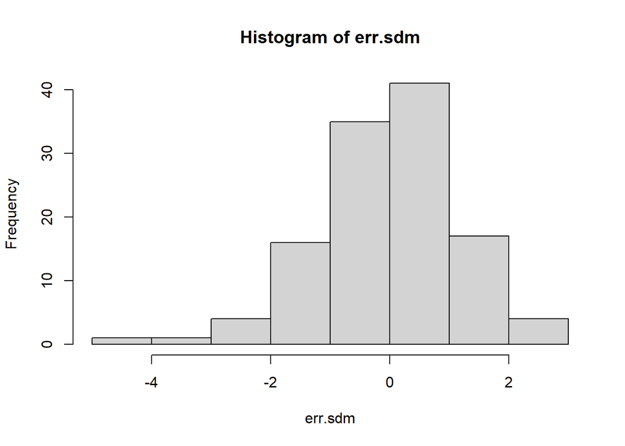

```r
hist(err.sdm)
```

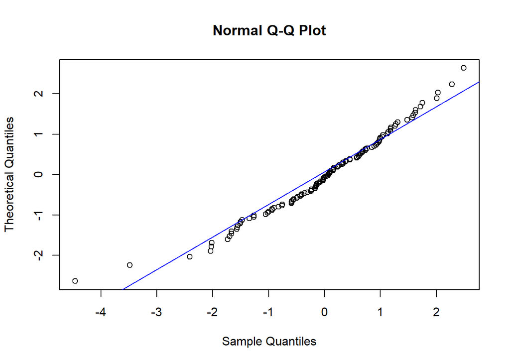

```r
qqnorm(err.sdm,datax=T)
qqline(rnorm(length(err.sdm),mean(err.sdm),sd(err.sdm)),datax=T, col="blue")
```

```r
bptest.Sarlm(sdm) #inputnya adalah modelnya
```

```
##
##  studentized Breusch-Pagan test
##
## data:
## BP = 2.774, df = 4, p-value = 0.5963
```

```r
moran.test(err.sdm, listw=ww, alternative="two.sided", zero.policy = TRUE)
```

```
##
##  Moran I test under randomisation
##
## data:  err.sdm
## weights: ww
##
## Moran I statistic standard deviate = -0.59546, p-value = 0.5515
## alternative hypothesis: two.sided
## sample estimates:
## Moran I statistic       Expectation          Variance
##      -0.039895225      -0.008474576       0.002784333
```

## Goodness of Fits (Model Terbaik)

Model regresi terbaik ditentukan berdasarkan nilai AIC yang dihasilkan dari masing-masing model. Model terbaik akan menghasilkan nilai AIC yang kecil. Hasilnya adalah sebagai berikut:

```r
df <- data.frame("Model" = c("OLS (Regresi KlasiK)","SAR","SEM","SARMA", "SDM"),
           "AIC" = c(AIC(ols),AIC(sar), AIC(sem),AIC(SARMA), AIC(sdm)))

df
```

```
##                  Model      AIC
## 1 OLS (Regresi KlasiK) 421.3205
## 2                  SAR 398.0970
## 3                  SEM 390.2637
## 4                SARMA 391.2017
## 5                  SDM 391.2745
```

| Rincian | OLS | SAR | SEM | SARMA | SDM |
| --- | --- | --- | --- | --- | --- |
| AIC | 421.321 | 398.1 | 390.26 | 391.2 | 391.27 |
| p-value dari Rho | NA | 0.000 | NA | 0.195 | 0.000 |
| p-value dari Lambda | NA | NA | 0.000 | 0.000 | NA |
| Kenormalan (p-value) | 0.225 | 0.632 | 0.0471 | 0.064 | 0.087 |
| Homoskedastisitas (p-value) | 0.459 | 0.261 | 0.638 | 0.526 | 0.596 |
| Kebebasan Sisaan (p-value) | 0.000 | 0.0055 | 0.582 | 0.712 | 0.552 |

Berdasarkan output diatas, model SEM adalah model yang terbaik berdasarkan nilai AIC-nya. Hal ini juga sejalan dengan lambda yang signifikan (p-value 0.000). Akan tetapi model SEM tidak memenuhi asumsi kenormalan. Oleh karena itu, model spasial yang dipilih adalah model SARMA karena model memiliki nilai AIC yang kecil dari model SAR dan OLS, serta hampir setara dengan model SEM. Hasil uji asumsi sisaan juga menunjukkan bahwa model SARMA telah memenuhi asumsi kenormalan, kehomogenan ragam, dan kebebasan.

## Interpretasi dan Kesimpulan

Karena Model SARMA memiliki spillover, maka perlu diinterpretasi dengan memperhatikan spillovernya. Interpretasi koefisien pada model regresi spasial dijelaskan dengan efek langsung, tidak langsung, dan total dari setiap peubah.

```r
sum <- summary(SARMA)
sum
```

```
##
## Call:
## sacsarlm(formula = y ~ x1 + x2, data = data, listw = ww, zero.policy = TRUE)
##
## Residuals:
##      Min       1Q   Median       3Q      Max
## -4.53574 -0.59853  0.10686  0.78564  2.55146
##
## Type: sac
## Coefficients: (asymptotic standard errors)
##               Estimate Std. Error z value  Pr(>|z|)
## (Intercept) -37.670168   2.567539 -14.672 < 2.2e-16
## x1            0.530517   0.015036  35.282 < 2.2e-16
## x2            0.286556   0.011748  24.392 < 2.2e-16
##
## Rho: 0.083991
## Asymptotic standard error: 0.064873
##     z-value: 1.2947, p-value: 0.19543
## Lambda: 0.47951
## Asymptotic standard error: 0.11669
##     z-value: 4.1093, p-value: 3.9689e-05
##
## LR test value: 34.119, p-value: 3.9012e-08
##
## Log likelihood: -189.6009 for sac model
## ML residual variance (sigma squared): 1.3555, (sigma: 1.1642)
## Number of observations: 119
## Number of parameters estimated: 6
## AIC: 391.2, (AIC for lm: 421.32)
```

```r
# Spill over
Im = impacts(SARMA, listw = ww)
Im
```

```
## Impact measures (sac, exact):
##       Direct   Indirect     Total
## x1 0.5311153 0.04804610 0.5791614
## x2 0.2868790 0.02595184 0.3128308
```

```r
# Efek Umpan Balik
koef = sum$coefficients[-1]
diref = Im$direct
umbal = diref-koef
cbind.data.frame(Koefisien=koef,EfekLangsung=diref,UmpanBalik=umbal)
```

```
##    Koefisien EfekLangsung   UmpanBalik
## x1 0.5305173    0.5311153 0.0005980483
## x2 0.2865560    0.2868790 0.0003230325
```

Berikut ini adalah interpretasinya:

*Peubah Penjelas X1*

**Efek Marginal untuk Model Lainnya**

```r
# Spill over
Im2 = impacts(sar, listw = ww)
Im2
```

```
## Impact measures (lag, exact):
##       Direct   Indirect     Total
## x1 0.5370876 0.15600347 0.6930911
## x2 0.2930588 0.08512239 0.3781812
```

```r
# Spill over
Im3 = impacts(sdm, listw = ww)
Im3
```

```
## Impact measures (mixed, exact):
##       Direct   Indirect     Total
## x1 0.5339407 0.09751864 0.6314593
## x2 0.2920035 0.07177461 0.3637781
```